# Introduction to R, part 1i

Steve Simon

Monday, August 10, 2016

This program is part of a series of R programs for the Introduction to R class. This program shows you how to draw scatterplots.

```r
R.version.string
```

```
## [1] "R version 3.4.3 (2017-11-30)"
```

```r
Sys.Date()
```

```
## [1] "2018-02-20"
```

If you need to, you can clean house and then re-load the data that you created earlier.

```r
ls()
```

```
## [1] "arm.measures"    "f"               "fd"              "fd1"
## [5] "fd2"             "fn"              "lb"              "leg.measures"
## [9] "overall_summary"
```

```r
rm(list=ls())
load("~/introduction-to-r-part1/bin/part1.RData")
ls()
```

```
## [1] "arm.measures"    "fd"              "fd1"             "fd2"
## [5] "fn"              "lb"              "leg.measures"    "overall_summary"
```

The best graphical way to display a relationship between two continuous variables is a scatterplot.

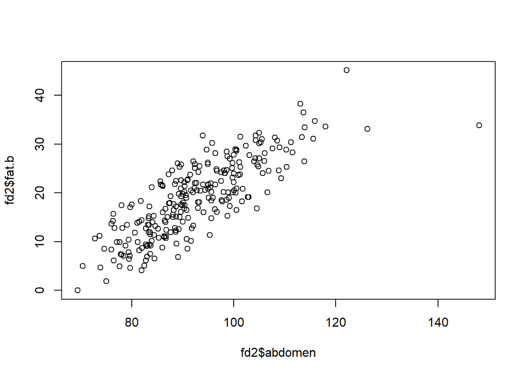

```r
plot(fd2$abdomen,fd2$fat.b)
```

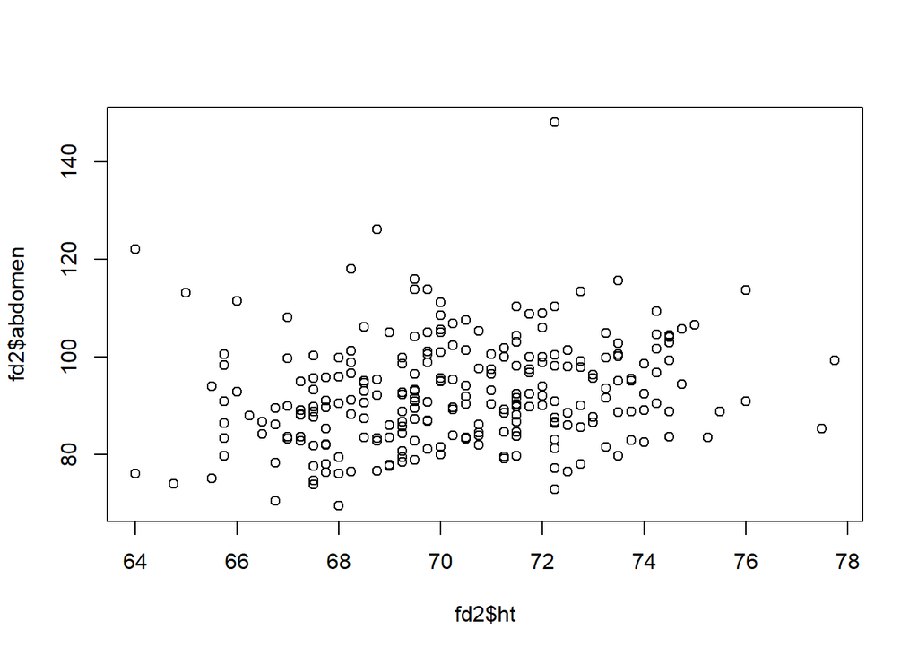

```r
plot(fd2$ht,fd2$abdomen)
```

There are lots of options available to customize your graph. Here are just a few. The xlab and ylab arguments in the plot function control what is displayed on the horizontal (x) and vertical (y) axes. The pch argument control what is used as the plotting character.

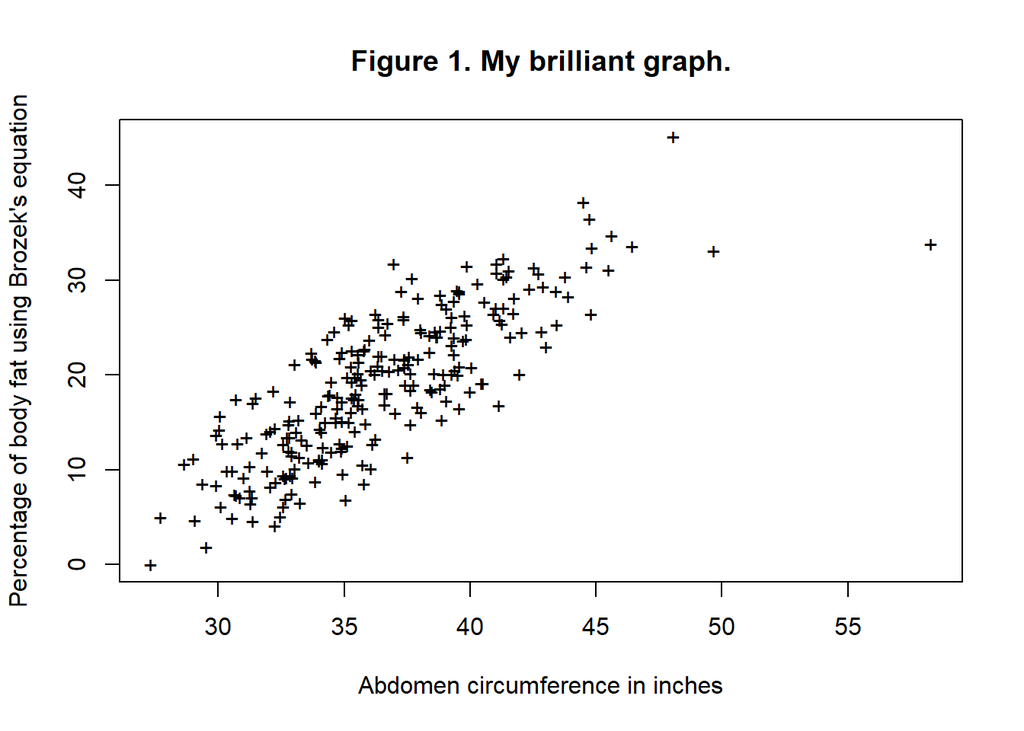

```r
plot(fd2$abdomen/2.54,fd2$fat.b,
     xlab="Abdomen circumference in inches",
     ylab="Percentage of body fat using Brozek's equation",
     pch="+")
title("Figure 1. My brilliant graph.")
```

Notice that you can do the units conversion “on the fly”. This doesn’t work on all functions.

## Adding trend lines

These scatterpltos often benefit by adding a trend line.

Here’s a linear regression trend line

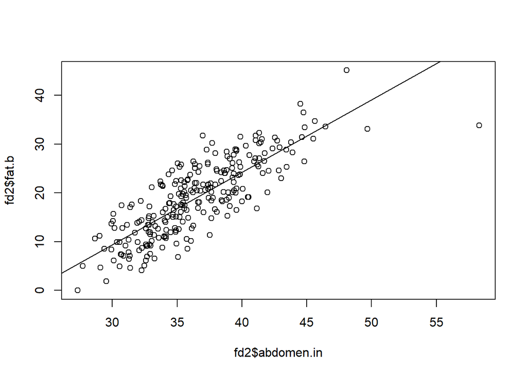

```r
fd2$abdomen.in <- fd2$abdomen/2.54
trend.line <- lm(fat.b~abdomen.in,data=fd2)
plot(fd2$abdomen.in,fd2$fat.b)
abline(trend.line)
```

Here’s a smooth curve.

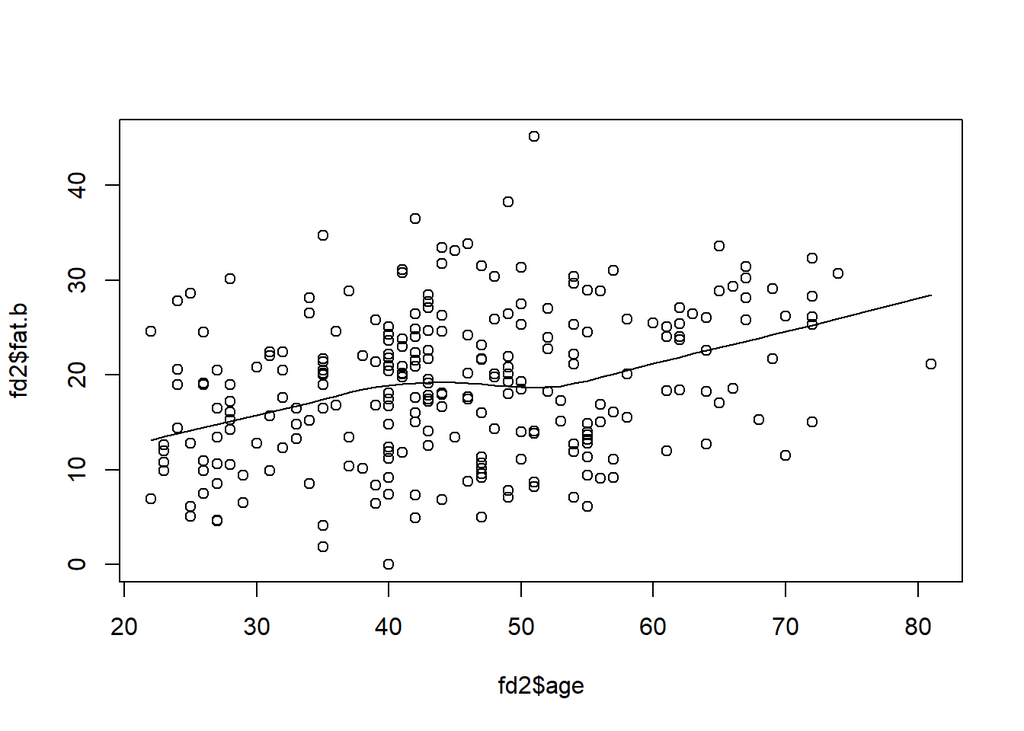

```r
smooth.curve <- lowess(fd2$age,fd2$fat.b)
plot(fd2$age,fd2$fat.b)
lines(smooth.curve)
```

## Try all of these things on a totally different data set.

There is a second data set on sleep in mammals. You can find a brief description of this data set at

–> http://www.statsci.org/data/general/sleep.html

and you can download the actual data at

–> http://www.statsci.org/data/general/sleep.txt

Notice that the last three variables are ordinal, but for the purposes of this class, we will treat them the same as the other variables.

## Read the file into R

Notice that this file has variable names at the very top. Look at the help file for read.table and see what option you might choose here. Display the first few rows and the last few rows.

As noted in each of the R commands shown below, I will remove the answers before I distribute this file to the students.

```r
fn <- "http://www.statsci.org/data/general/sleep.txt"
sl <- read.table(file=fn,header=TRUE)
head(sl)
```

```
##                  Species   BodyWt BrainWt NonDreaming Dreaming TotalSleep
## 1        Africanelephant 6654.000  5712.0          NA       NA        3.3
## 2 Africangiantpouchedrat    1.000     6.6         6.3      2.0        8.3
## 3              ArcticFox    3.385    44.5          NA       NA       12.5
## 4   Arcticgroundsquirrel    0.920     5.7          NA       NA       16.5
## 5          Asianelephant 2547.000  4603.0         2.1      1.8        3.9
## 6                 Baboon   10.550   179.5         9.1      0.7        9.8
##   LifeSpan Gestation Predation Exposure Danger
## 1     38.6       645         3        5      3
## 2      4.5        42         3        1      3
## 3     14.0        60         1        1      1
## 4       NA        25         5        2      3
## 5     69.0       624         3        5      4
## 6     27.0       180         4        4      4
```

```r
tail(sl)
```

```
##                 Species BodyWt BrainWt NonDreaming Dreaming TotalSleep
## 57               Tenrec  0.900     2.6        11.0      2.3       13.3
## 58            Treehyrax  2.000    12.3         4.9      0.5        5.4
## 59            Treeshrew  0.104     2.5        13.2      2.6       15.8
## 60               Vervet  4.190    58.0         9.7      0.6       10.3
## 61         Wateropossum  3.500     3.9        12.8      6.6       19.4
## 62 Yellow-belliedmarmot  4.050    17.0          NA       NA         NA
##    LifeSpan Gestation Predation Exposure Danger
## 57      4.5        60         2        1      2
## 58      7.5       200         3        1      3
## 59      2.3        46         3        2      2
## 60     24.0       210         4        3      4
## 61      3.0        14         2        1      1
## 62     13.0        38         3        1      1
```

Your homework assignment for Part 1 is available at http://www.pmean.com/15/images/homework.html.

## If there is time.

If there is time, a third data set is described at

–> http://www.amstat.org/publications/jse/datasets/body.txt

and the data itself is at

–> http://www.amstat.org/publications/jse/datasets/body.dat.txt

We created a few new objects, so you might want to save things here before proceeding to the next section.

```r
save.image("~/introduction-to-r-part1/bin/part1.RData")
```

There is no quiz for part 1i.